# AssignmentMP2

Srishti Patil

2024-10-23

```r
library(readr)
library(fpp)
library(fpp2)
library(forecast)
```

#Loading dataset

```r
insurance <- read_csv("C:/Users/Srishti/Desktop/FALL24/BF/AssignmentMP2/insurance.csv")
```

```
## ──────────────────────────────────────────────────────── Delimiter: "," dbl
## (3): ...1, Quotes, TV.advert
```

```r
head(insurance)
```

```
## # A tibble: 6 × 3
##    ...1 Quotes TV.advert
##   <dbl>  <dbl>     <dbl>
## 1     1   13.0      7.21
## 2     2   15.4      9.44
## 3     3   13.2      7.53
## 4     4   13.0      7.21
## 5     5   15.4      9.44
## 6     6   11.7      6.42
```

1. Create Timeseries

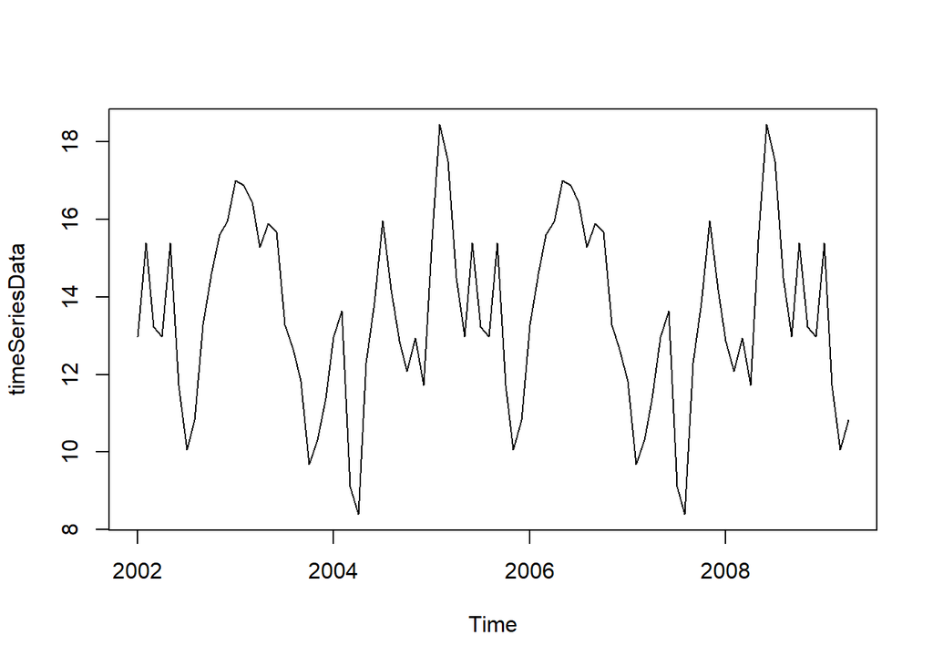

```r
timeSeriesData <- ts(insurance$Quotes, frequency = 12 , start = c(2002,1), end = c(2009,4))
plot(timeSeriesData)
```

2. Verify how much history to include in your analysis.

As the data shows irregular fluctuations over the time, we will include the entire dataset for better forecasting and analysis.

3. Hypothesize if the dataset has trend, seasonality, or both. This time series, spanning approximately 8 years (2002–2009), provides enough history for analysis. The data exhibits regular peaks and troughs, suggesting a strong seasonal component. However, there’s no clear upward or downward trend, indicating that the trend component is likely weak or absent.
4. Verify using Acf

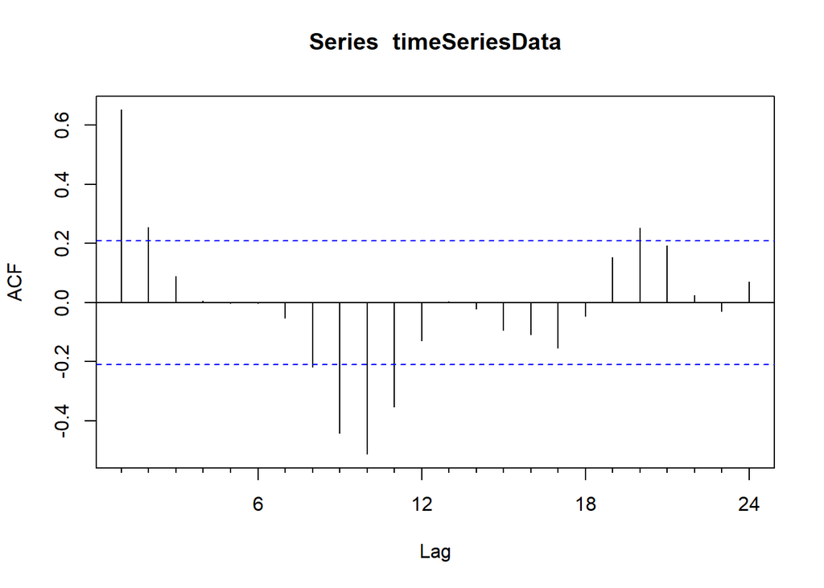

```r
Acf(timeSeriesData)
```

5. Verify using decomposition

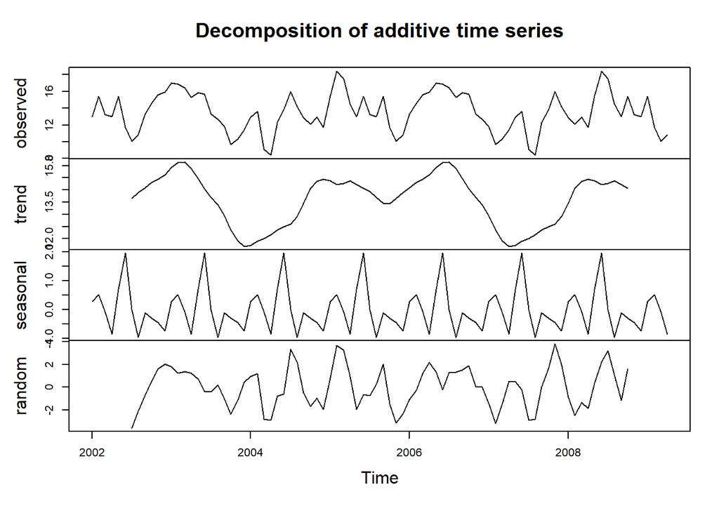

```r
decomposed_data <- decompose(timeSeriesData)
plot(decomposed_data)
```

The decomposition plot also confirms seasonality, as seen in the periodic fluctuations in the “seasonal” component. The decomposition plot shows a gradual increase and decrease in the trend component over time, indicating a weak trend. The trend is not strong or consistent, but it does fluctuate slightly across the years.

6. Chose an accuracy measure For the given forecast I choose MAE or MAPE as it would be the best.
7. Create a forecast model for the next 12 months. Include Naive, Average, Exponential Smoothing, HoltWinters, and Decomposition (both types).

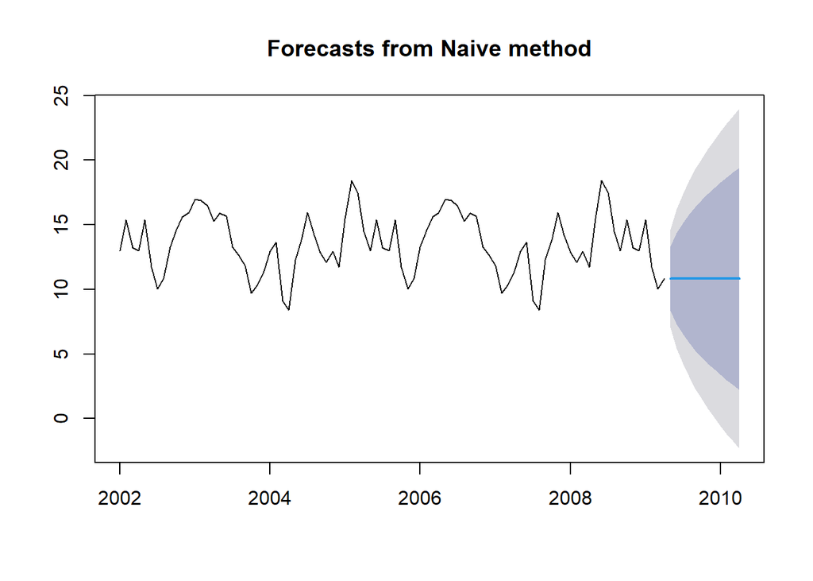

```r
# Naive forecast
naive_forecast <- naive(timeSeriesData, h=12)
plot(naive_forecast)
```

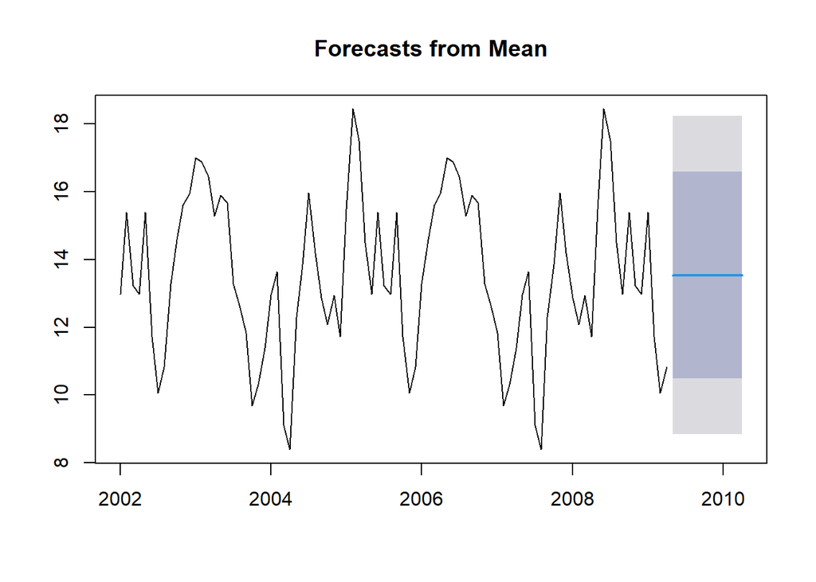

```r
# Mean/average method
mean_forecast <- meanf(timeSeriesData, h=12)
plot(mean_forecast)
```

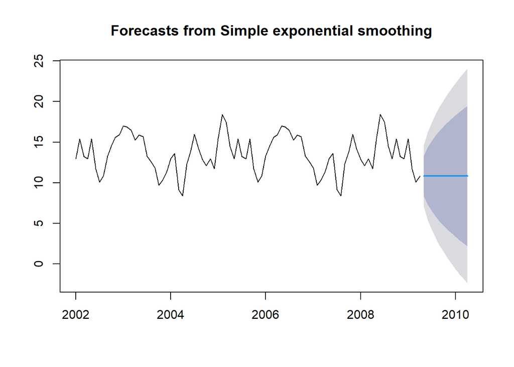

```r
# Exponential Smoothing
ses_forecast <- ses(timeSeriesData, h=12)
plot(ses_forecast)
```

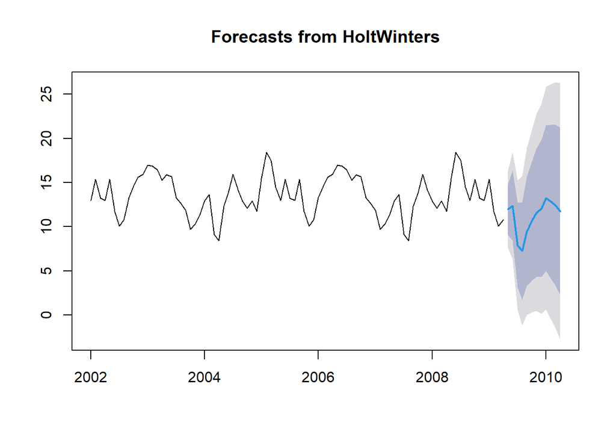

```r
# Holt-Winters forecast
hw_forecast <- HoltWinters(timeSeriesData)
hw_forecast_future <- forecast(hw_forecast, h=12)
plot(hw_forecast_future)
```

```r
# Moving Averages
MA5_forecast <- ma(timeSeriesData,order=12)
print(MA5_forecast)
```

```
##           Jan      Feb      Mar      Apr      May      Jun      Jul      Aug
## 2002       NA       NA       NA       NA       NA       NA 13.66422 13.89402
## 2003 14.92296 15.13330 15.14841 14.88400 14.45951 14.04893 13.69077 13.38699
## 2004 11.72694 11.90308 12.01075 12.15358 12.36300 12.48673 12.60588 12.91121
## 2005 14.38739 14.22240 14.27662 14.36672 14.23183 14.07468 13.94619 13.69432
## 2006 14.09039 14.32090 14.43808 14.62377 14.92296 15.13330 15.14841 14.88400
## 2007 12.94626 12.35389 11.91744 11.69172 11.72694 11.90308 12.01075 12.15358
## 2008 13.46033 14.06316 14.34511 14.43714 14.38739 14.22240 14.27662 14.36672
## 2009       NA       NA       NA       NA
##           Sep      Oct      Nov      Dec
## 2002 14.09039 14.32090 14.43808 14.62377
## 2003 12.94626 12.35389 11.91744 11.69172
## 2004 13.46033 14.06316 14.34511 14.43714
## 2005 13.45486 13.43640 13.66422 13.89402
## 2006 14.45951 14.04893 13.69077 13.38699
## 2007 12.36300 12.48673 12.60588 12.91121
## 2008 14.23183 14.07468       NA       NA
## 2009
```

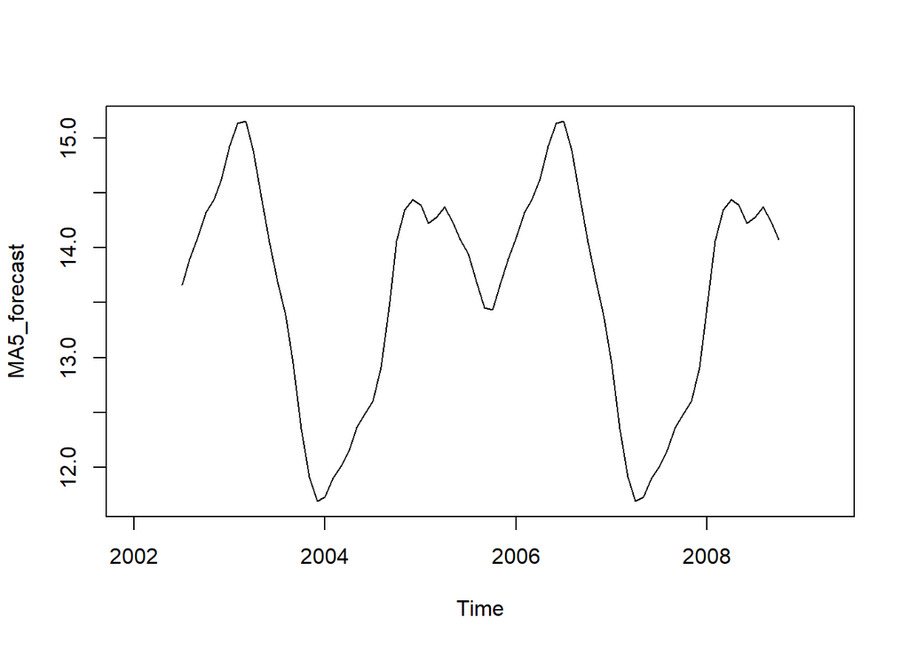

```r
plot(MA5_forecast)
```

```r
# decomposition
decomp_add <- decompose(timeSeriesData, type="additive")
decomp_mult <- decompose(timeSeriesData, type="multiplicative")

# Decomposition Forecasts using trend component
decomp_add_forecast <- forecast(decomp_add$trend, h=12)
decomp_mult_forecast <- forecast(decomp_mult$trend, h=12)
```

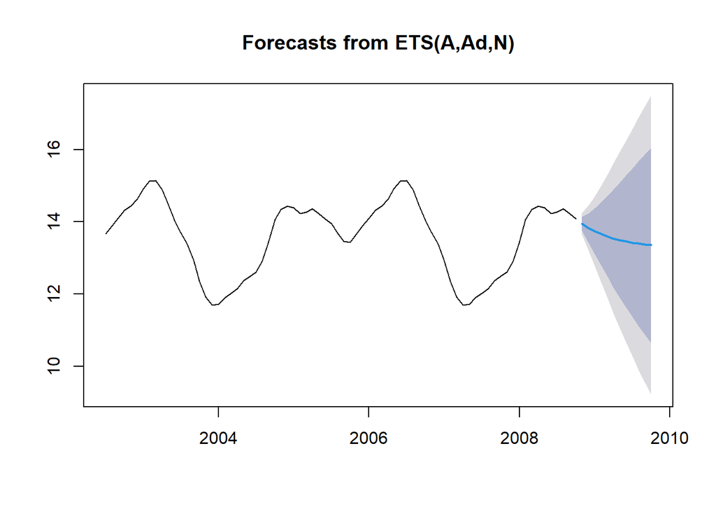

```r
plot(decomp_add_forecast)
plot(decomp_mult_forecast)
```

[output not shown]

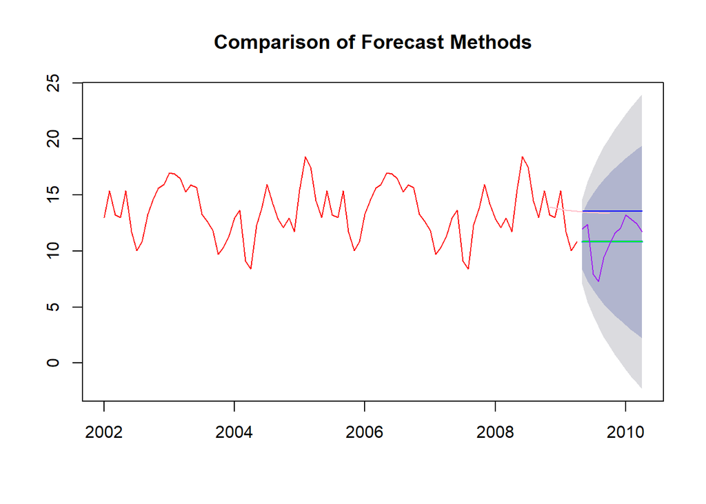

```r
mean_accuracy <- accuracy(mean_forecast)
naive_accuracy <- accuracy(naive_forecast)
ses_accuracy <- accuracy(ses_forecast)
hw_accuracy <- accuracy(hw_forecast_future)
decomp_add_accuracy <- accuracy(decomp_add_forecast)
decomp_mult_accuracy <- accuracy(decomp_mult_forecast)



plot(naive_forecast, main="Comparison of Forecast Methods", col="red")
lines(mean_forecast$mean, col="blue")
lines(ses_forecast$mean, col="green")
lines(hw_forecast_future$mean, col="purple")
lines(decomp_add_forecast$mean, col="yellow")
lines(decomp_mult_forecast$mean, col="pink")
```

Due to the trend and seasonality available in the data, MAE and MAPE would generally provide a more stable metric for accuracy. Unlike RMSE, MAE does not penalize larger errors and provides a balanced view of average error. For forecast errors in percentage terms relative to the actual values, MAPE is best forecasting technique.

8. Show model rank with accuracy measures Ranking of Models Based on MAE:

Additive Decomposition – 0.1197 Multiplicative Decomposition – 0.1197 Exponential Smoothing – 1.5808 Naive – 1.5989 Holt-Winters – 1.7541 Mean – 1.9239

Hence, The Decomposition (Additive and Multiplicative) models rank the highest and provide the best forecast accuracy based on the given metrics. These models are likely the best choice for forecasting the next 12 months.

```r
accuracy_df <- data.frame(
  Model = c( "Additive Decomposition", "Multiplicative Decomposition","Holt-Winters", "Naive", "Mean", "Exponential Smoothing"),
ME= c( decomp_add_accuracy[1], decomp_mult_accuracy[1],hw_accuracy[1], naive_accuracy[1], mean_accuracy[1],ses_accuracy[1]),
  RMSE = c( decomp_add_accuracy[2], decomp_mult_accuracy[2],hw_accuracy[2], naive_accuracy[2], mean_accuracy[2],ses_accuracy[2]),
  MAE = c( decomp_add_accuracy[3], decomp_mult_accuracy[3],hw_accuracy[3], naive_accuracy[3], mean_accuracy[3],ses_accuracy[3]),
  MPE = c( decomp_add_accuracy[4], decomp_mult_accuracy[4],hw_accuracy[4], naive_accuracy[4], mean_accuracy[4],ses_accuracy[4]),
  MAPE = c( decomp_add_accuracy[5], decomp_mult_accuracy[5],hw_accuracy[5], naive_accuracy[5], mean_accuracy[5],ses_accuracy[5]),
  MASE = c( decomp_add_accuracy[6], decomp_mult_accuracy[6],hw_accuracy[6], naive_accuracy[6], mean_accuracy[6],ses_accuracy[6]),
  ACF1 = c( decomp_add_accuracy[7], decomp_mult_accuracy[7],hw_accuracy[7], naive_accuracy[7], mean_accuracy[7],ses_accuracy[7])
)

print(accuracy_df)
```

```
##                          Model            ME      RMSE       MAE         MPE
## 1       Additive Decomposition -8.015951e-04 0.1441344 0.1196757  0.02184605
## 2 Multiplicative Decomposition -8.015951e-04 0.1441344 0.1196757  0.02184605
## 3                 Holt-Winters -1.239926e-01 2.2205376 1.7540618 -2.15935918
## 4                        Naive -2.468805e-02 1.9376180 1.5989303 -1.36959892
## 5                         Mean  6.863542e-16 2.3348014 1.9239091 -3.28263134
## 6        Exponential Smoothing -2.441381e-02 1.9265907 1.5808030 -1.35422015
##         MAPE       MASE       ACF1
## 1  0.8827177 0.07336531 0.46166717
## 2  0.8827177 0.07336531 0.46166717
## 3 13.3343006 0.58665461 0.21652403
## 4 12.3732158 0.53477014 0.06874541
## 5 15.1386705 0.64346088 0.65157290
## 6 12.2329756 0.52870736 0.06899439
```

Given the ranking of models based on accuracy metrics (MAE), I would choose Decomposition(Additive and Multiplicative) or Exponential Smoothing models for forecasting the next 12 months:

###Chosen Models for Forecasting: Reason: 1.Decomposition (Additive and Multiplicative): This model performed the best across the key accuracy measures (MAE). The decomposition models capture both the trend and seasonality effectively, which is crucial when your data exhibits these patterns. Decomposition will split the data into the trend, seasonality, and residuals, allowing us to forecast each component separately and combine them to get a more accurate overall forecast.

### How I’m Going to Use These Models for Forecasting:

1. Decomposition Model:
   - First, decompose the historical time series data into its trend, seasonal, and residual components.
   - Forecast each component separately for the next 12 months.
   - Combine the forecasted trend, seasonality, and residual components to generate the final forecast for the next 12 months.

```r
# Additive decomposition using STL
decomp_add <- stl(timeSeriesData, s.window = "periodic")
decomp_add_forecast <- forecast(decomp_add, h = 12)
print(decomp_add_forecast)
```

```
##          Point Forecast     Lo 80    Hi 80       Lo 95    Hi 95
## May 2009       12.54178 10.323155 14.76040  9.14868676 15.93487
## Jun 2009       13.05577  9.918319 16.19322  8.25745305 17.85409
## Jul 2009       11.62734  7.784829 15.46985  5.75072591 17.50396
## Aug 2009       10.70455  6.267635 15.14146  3.91887410 17.49022
## Sep 2009       11.57045  6.609857 16.53105  3.98387621 19.15703
## Oct 2009       11.37849  5.944449 16.81253  3.06784071 19.68914
## Nov 2009       11.17479  5.305369 17.04421  2.19828391 20.15130
## Dec 2009       10.91929  4.644629 17.19396  1.32302170 20.51557
## Jan 2010       12.19379  5.538516 18.84907  2.01542406 22.37216
## Feb 2010       12.25794  5.242667 19.27321  1.52900606 22.98687
## Mar 2010       11.33644  3.978767 18.69411  0.08385055 22.58903
## Apr 2010       10.82266  3.137830 18.50749 -0.93027455 22.57560
```

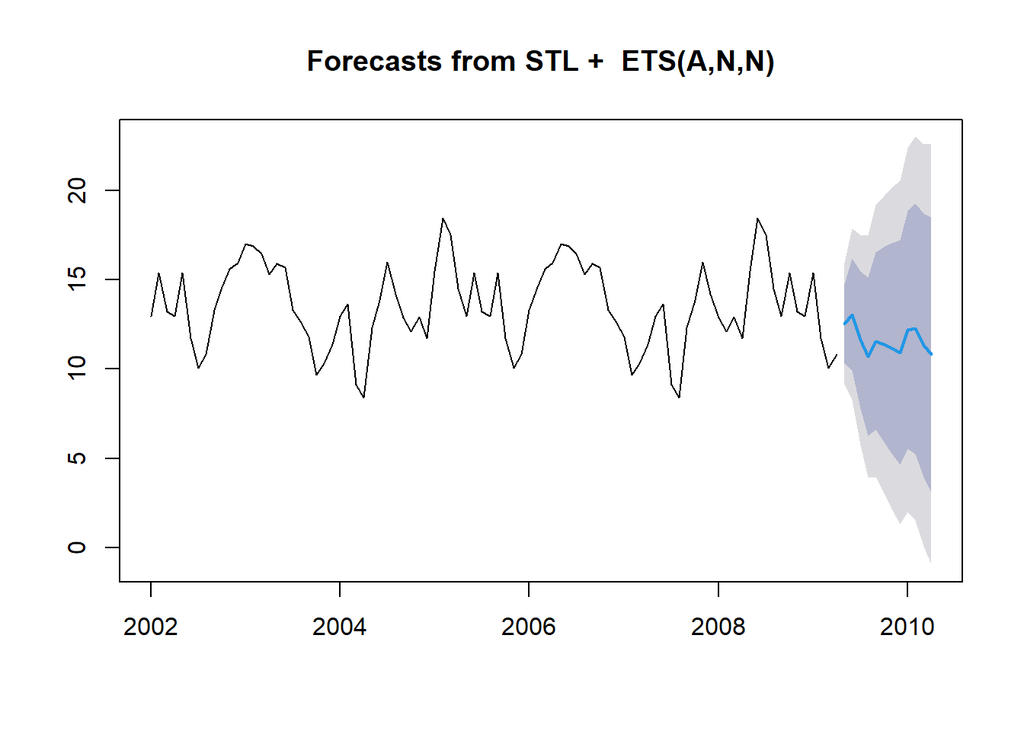

```r
plot(decomp_add_forecast)
```

```r
# Multiplicative decomposition using STL
log_flight_ts <- log(timeSeriesData)
decomp_mult <- stl(log_flight_ts, s.window = "periodic")
decomp_mult_forecast <- forecast(decomp_mult, h = 12)
decomp_mult_forecast$mean <- exp(decomp_mult_forecast$mean)
print(decomp_mult_forecast)
```

```
##          Point Forecast    Lo 80    Hi 80    Lo 95    Hi 95
## May 2009       12.43687 2.347264 2.694067 2.255471 2.785860
## Jun 2009       12.83854 2.307237 2.797666 2.177429 2.927475
## Jul 2009       11.43817 2.136636 2.737276 1.977656 2.896256
## Aug 2009       10.75287 2.028396 2.721949 1.844823 2.905522
## Sep 2009       11.62589 2.065528 2.840941 1.860289 3.046180
## Oct 2009       11.38126 2.007258 2.856677 1.782431 3.081505
## Nov 2009       11.19609 1.956827 2.874302 1.713986 3.117143
## Dec 2009       11.04326 1.911410 2.892231 1.651803 3.151838
## Jan 2010       12.13937 1.976296 3.016612 1.700941 3.291967
## Feb 2010       12.04947 1.940727 3.037315 1.650477 3.327564
## Mar 2010       11.18320 1.839358 2.989468 1.534942 3.293884
## Apr 2010       10.82268 1.781019 2.982269 1.463067 3.300220
```

[figure not shown]

```r
plot(decomp_mult_forecast)
```